# Introduction to the normR package

```r
#Overlap of H3K4me3 with promoters
promoters <- promoters(genes, upstream = 2000, downstream = 2000)
overlapOdds(k4me3Ranges, promoters)
```

```
##
##  Fisher's Exact Test for Count Data
##
## data:  m
## p-value < 2.2e-16
## alternative hypothesis: true odds ratio is greater than 1
## 95 percent confidence interval:
##  6.665838      Inf
## sample estimates:
## odds ratio
##   7.738937
```

```r
#Overlap of H3K36me3 with H3K4me3
k36me3Ranges <- getRanges(k36me3Fit, fdr = 0.05)
overlapOdds(k36me3Ranges, k4me3Ranges)
```

```
##
##  Fisher's Exact Test for Count Data
##
## data:  m
## p-value = 4.173e-06
## alternative hypothesis: true odds ratio is greater than 1
## 95 percent confidence interval:
##  1.306727      Inf
## sample estimates:
## odds ratio
##   1.527935
```

```r
#Overlap of H3K36me3 with H3K4me3 at promoter regions
overlapOdds(k36me3Ranges[countOverlaps(k36me3Ranges, promoters) != 0],
            k4me3Ranges[countOverlaps(k4me3Ranges, promoters) != 0])
```

```
##
##  Fisher's Exact Test for Count Data
##
## data:  m
## p-value < 2.2e-16
## alternative hypothesis: true odds ratio is greater than 1
## 95 percent confidence interval:
##  7.920713      Inf
## sample estimates:
## odds ratio
##   9.676087
```

```r
#Overlap of H3K36me3 with H3K4me3 in genes
overlapOdds(k36me3Ranges[countOverlaps(k36me3Ranges, genes) != 0],
            k4me3Ranges[countOverlaps(k4me3Ranges, genes) != 0])
```

```
##
##  Fisher's Exact Test for Count Data
##
## data:  m
## p-value < 2.2e-16
## alternative hypothesis: true odds ratio is greater than 1
## 95 percent confidence interval:
##  2.390976      Inf
## sample estimates:
## odds ratio
##    2.85357
```

```r
#Overlap of H3K36me3 in genes
overlapOdds(k36me3Ranges, genes)
```

```
##
##  Fisher's Exact Test for Count Data
##
## data:  m
## p-value < 2.2e-16
## alternative hypothesis: true odds ratio is greater than 1
## 95 percent confidence interval:
##  4.986738      Inf
## sample estimates:
## odds ratio
##   5.522417
```

```r
#Overlap of H3K36me3 with promoters
overlapOdds(k36me3Ranges, promoters(genes, 1500, 1500))
```

```
##
##  Fisher's Exact Test for Count Data
##
## data:  m
## p-value < 2.2e-16
## alternative hypothesis: true odds ratio is greater than 1
## 95 percent confidence interval:
##  2.426846      Inf
## sample estimates:
## odds ratio
##   2.680547
```

### 3.1.2 Exporting Results

While there exist a plethora of analysis options of normR results within R, `exportR()` provides functionality to write results to a file. To export coordinates of enriched regions, the widely used [BED format](https://genome.ucsc.edu/FAQ/FAQformat.html#format1) is applicable. It is human-readable and can be imported in common genome browsers, *e.g.* [UCSC genome browser](https://genome.ucsc.edu/cgi-bin/hgTracks) or [IGV](http://bioviz.org/). To export the background-normalized enrichment, the binary [bigWig format](https://genome.ucsc.edu/FAQ/FAQformat.html#format6.1) is used. Check `?exportR` for more options.

```r
#export coordinates of significantly (FDR <= 0.05) enriched regions
exportR(k4me3Fit, filename = "k4me3Fit.bed", type = "bed", fdr = 0.05)
exportR(k36me3Fit, filename = "k36me3Fit.bed", type = "bed", fdr = 0.05)

#export background-normalized enrichment
exportR(k4me3Fit, filename = "k4me3Fit.bw", type = "bigWig")
exportR(k36me3Fit, filename = "k36me3Fit.bw", type = "bigWig")
```

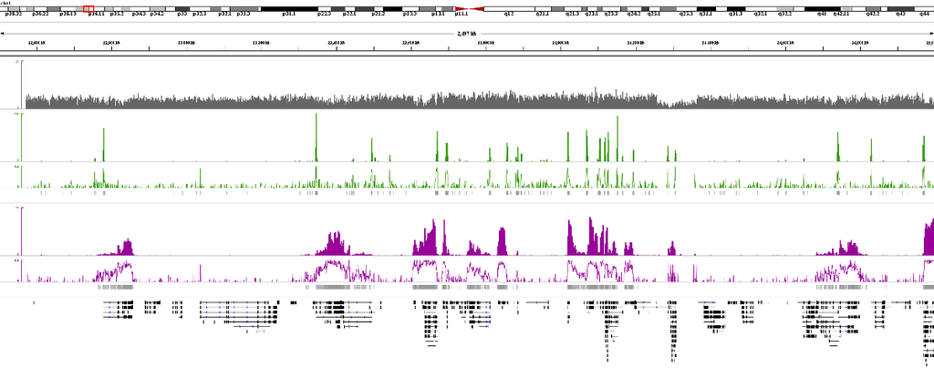

**IGV browser shot of Input (grey), H3K4me3 (green) and H3K36me3 (purple) alignment data (bars), normalized enrichment, *i.e.* “bigWig” files, (lines) and enriched regions, *i.e.* “bed” files (boxes below respective tracks).**

## 3.2 `diffR()`: Calling Differential Enrichment without a Control Experiment

Normalization and difference calling are inseparable in calling ChIP-seq enrichment. Following this notion, a direct comparison of two ChIP-seq tracks can be performed with `diffR()`. In many studies, researchers are interested in conditional changes in ChIP-seq enrichment. Below, we exemplify this analysis by joint analysis of H3K4me3 and H3K36me3 ChIP-seq data. Because we already counted `k4me3Bamfile` and `k36me3Bamfile` already in `k4me3Fit` and `k36me3Fit`, respectively, we can use these counts directly. Note that, in this case, the `genome` has be set to a `GenomicRanges` object specifying the genomic regions. We can extract this from either one of the `NormRFit` objects.

```r
#We could use read counts from above NormRFit objects
k4k36Dif <- diffR(treatment = getCounts(k4me3Fit)$treatment,
                  control   = getCounts(k36me3Fit)$treatment,
                  genome    = getRanges(k4me3Fit),
                  verbose   = FALSE)
#<or> (unnecessarily) count again
#k4k36Dif <- diffR(treatment = k4me3Bamfile, control = k36me3Bamfile,
#                  genome = genome, verbose = FALSE)

#summary statistics
summary(k4k36Dif)
```

```
## NormRFit-class object
##
## Type:                  'diffR'
## Number of Regions:     997003
## Number of Components:  3
## Theta* (naive bg):     0.379
## Background component B: 2
##
## +++ Results of fit +++
## Mixture Proportions:
##    Class 1    Background       Class 2
##      49.8%         29.5%         20.7%
## Theta:
##    Class 1    Background       Class 2
##     0.0183        0.4798        0.9726
##
## Bayesian Information Criterion:  48069
##
## +++ Results of binomial test +++
## T-Filter threshold: 6
## Number of Regions filtered out: 994238
## Significantly different from background B based on q-values:
## TOTAL:
##           ***       **        *        .              n.s.
## Bins        0     1896      412      172      126      159
## %        0.00    20.07    24.43    26.25    27.58     1.68
## Class 1:
##           ***       **        *        .              n.s.
## Bins        0     1567      321      113       81      683
## %        0.00    56.67    11.61     4.09     2.93    24.70
## Class 2:
##           ***       **        *        .              n.s.
## Bins        0      329       91       59       45     2241
## %        0.00    11.90     3.29     2.13     1.63    81.05
## ---
## Signif. codes:  0 '***' 0.001 '**' 0.01 '*' 0.05 '.' 0.1 '  ' 1 'n.s.'
```

```r
exportR(k4k36Dif, filename = "k4k36Dif.bed", type = "bed", fdr = 0.05)
exportR(k4k36Dif, filename = "k4k36Dif.bw", type = "bigWig")
```

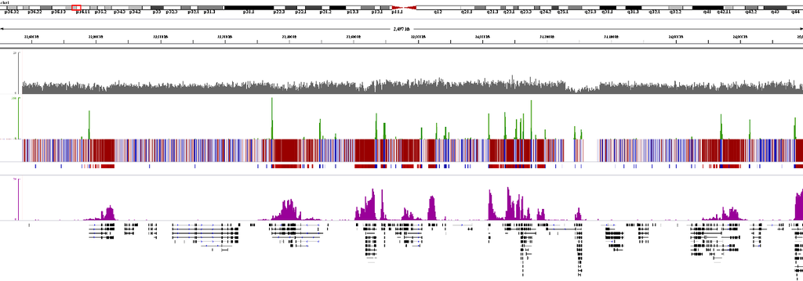

**IGV browser shot of Input (grey), H3K4me3 (green) and H3K36me3 (purple) alignment data. Background normalized difference is plotted as a heatmap, *i.e.* “bigWig” file, and differential regions are plotted as boxes, *i.e.* “bed” file (blue: treatment (H3K4me3) enriched, red: control (H3K36me3) enriched).**

## 3.3 `regimeR()`: Identify Enrichment Regimes in ChIP-seq Experiments

The two sections above aimed at discerning enrichment from background. The extendable normR approach also allows for identification of different enrichment regimes with `regimeR()` by increasing the number of model components.

Let’s start with 3 components (Background + 2 Enrichment Regimes) for H3K4me3. By using two enrichment regimes, we may uncover effects of sample heterogeneity affecting transcriptional initiation of certian genes.

```r
k4me3Regimes <- regimeR(treatment = getCounts(k4me3Fit)$treatment,
                         control   = getCounts(k4me3Fit)$control,
                         genome    = getRanges(k4me3Fit),
                         models    = 3,
                         verbose   = FALSE)
summary(k4me3Regimes)
```

```
## NormRFit-class object
##
## Type:                  'regimeR'
## Number of Regions:     997003
## Number of Components:  3
## Theta* (naive bg):     0.393
## Background component B: 1
##
## +++ Results of fit +++
## Mixture Proportions:
## Background       Class 1       Class 2
##     89.58%         7.64%         2.78%
## Theta:
## Background       Class 1       Class 2
##     0.0691        0.5496        0.9547
##
## Bayesian Information Criterion:  69872
##
## +++ Results of binomial test +++
## T-Filter threshold: 4
## Number of Regions filtered out: 988560
## Significantly different from background B based on q-values:
## TOTAL:
##            ***        **         *         .                n.s.
## Bins        41       448        80       123       113      7638
## %        0.401     4.778     5.560     6.762     7.866    74.634
## Class 1:
##            ***        **         *         .                n.s.
## Bins         0       245        80       123       113      7882
## %        0.000     2.902     0.948     1.457     1.338    93.355
## Class 2:
##            ***        **         *         .                n.s.
## Bins        41       203         0         0         0      8199
## %        0.486     2.404     0.000     0.000     0.000    97.110
## ---
## Signif. codes:  0 '***' 0.001 '**' 0.01 '*' 0.05 '.' 0.1 '  ' 1 'n.s.'
```

Now, we would like to use two enrichment regimes for H3K36me3. In this way, we might be able to classify genes of low and high transcriptional rates:

```r
k36me3Regimes <- regimeR(treatment = getCounts(k36me3Fit)$treatment,
                         control   = getCounts(k36me3Fit)$control,
                         genome    = getRanges(k36me3Fit),
                         models    = 3,
                         verbose   = FALSE)
summary(k36me3Regimes)
```

```
## NormRFit-class object
##
## Type:                  'regimeR'
## Number of Regions:     997003
## Number of Components:  3
## Theta* (naive bg):     0.514
## Background component B: 1
##
## +++ Results of fit +++
## Mixture Proportions:
## Background       Class 1       Class 2
##      69.2%         15.9%         14.9%
## Theta:
## Background       Class 1       Class 2
##     0.0776        0.5443        0.8858
##
## Bayesian Information Criterion:  126538
##
## +++ Results of binomial test +++
## T-Filter threshold: 4
## Number of Regions filtered out: 988119
## Significantly different from background B based on q-values:
## TOTAL:
##          ***      **       *       .            n.s.
## Bins       0    2130     211     237     157    6149
## %        0.0    13.4    14.7    16.2    17.2    38.6
## Class 1:
##           ***       **        *        .              n.s.
## Bins        0      780      202      237      157     7508
## %        0.00     8.78     2.27     2.67     1.77    84.51
## Class 2:
##            ***        **         *         .                n.s.
## Bins         0      1350         9         0         0      7525
## %        0.000    15.196     0.101     0.000     0.000    84.703
## ---
## Signif. codes:  0 '***' 0.001 '**' 0.01 '*' 0.05 '.' 0.1 '  ' 1 'n.s.'
```

We can now export the called regimes as bed files for browser display. Each track has two enrichment regimes which are shaded for their degree of significance. The export is done analogously to the cases described above:

```r
exportR(k4me3Regimes, filename = "k4me3Regimes.bed", type = "bed", fdr=0.05)
exportR(k36me3Regimes, filename = "k36me3Regimes.bed", type = "bed", fdr=0.05)
```

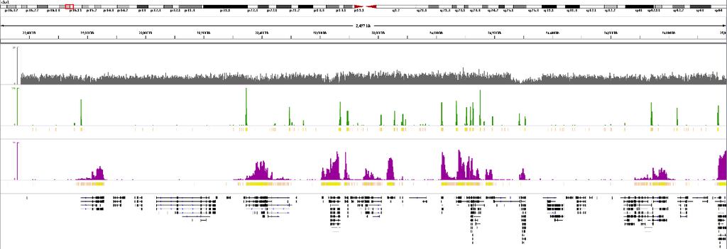

**IGV browser shot of Input (grey), H3K4me3 (green) and H3K36me3 (purple) alignment data. Regime calls are plotted as boxes below respective tracks (Yellow = low enrichment, Pink = high enrichment)**

# 4 Advanced Topics

In addition to the information covered above, it is recommend to have a look at help pages (`?`) of normR functions. Here, we would like to discuss three important points:

## 4.1 Change Read Counting Strategy with `NormRCountConfig-class`

It is very important how we count reads contained in the bamfile. The `NormRCountConfig-class` provides methods to define the counting strategy on single-end and paired-end alignment data:

```r
#Single End:
# Count in 500bp bins.
# Consider only reads with Mapping Quality >= 20.
# Filter reads for marked duplicates (e.g. with picard mark-duplicates)
# Shift the counting position for a read 100 bp downstream.
countConfigSE <- countConfigSingleEnd(binsize = 500, mapq = 20,
                                      filteredFlag = 1024, shift = 100)

#Paired End:
# Count in 500bp bins.
# Consider only reads with Mapping Quality >= 30.
# Count the midpoint of the aligned fragment instead of 5' ends.
# Consider only reads corresponding to fragments with size from 100 to 300bp
countConfigPE <- countConfigPairedEnd(binsize = 500, mapq = 30, midpoint=TRUE,
                                      tlenFilter = c(100, 300))

#Plug in the counting configuration into normR, e.g. in enrichR()
fit <- enrichR(treatment   = k4me3Bamfile,
               control     = inputBamfile,
               genome      = genome,
               countConfig = countConfigPE)
```

## 4.2 Analyzing Predefined Regions

You could do a fit on a set of pre-defined regions like promoters or known transcription factor binding sites. You need to count beforehand with `bamsignals`. Note, for the fit to work correctly these regions should be of same size.

```r
promoters <- promoters(genes, 1500, 1500)
#regions have identical size?
all(width(promoters) == 4000)
```

```
## [1] FALSE
```

```r
#Fit only on promoters
promotersFit <- enrichR(treatment = k4me3Bamfile, control = inputBamfile,
                        genome = promoters, verbose = FALSE)
summary(promotersFit)
```

```
## NormRFit-class object
##
## Type:                  'enrichR'
## Number of Regions:     265
## Number of Components:  2
## Theta* (naive bg):     0.891
## Background component B: 1
##
## +++ Results of fit +++
## Mixture Proportions:
## Background       Class 1
##      51.7%         48.3%
## Theta:
## Background       Class 1
##      0.125         0.943
##
## Bayesian Information Criterion:  98584
##
## +++ Results of binomial test +++
## T-Filter threshold: 4
## Number of Regions filtered out: 3
## Significantly different from background B based on q-values:
## TOTAL:
##          ***      **       *       .            n.s.
## Bins     101      36       1       4       3     117
## %       12.9    17.6    17.7    18.2    18.6    15.0
## ---
## Signif. codes:  0 '***' 0.001 '**' 0.01 '*' 0.05 '.' 0.1 '  ' 1 'n.s.'
```

## 4.3 Post-processing of Difference Calls with CNV information

```r
cnvs <- diffR(treatment   = treatmentInputBamfile,
              control     = controlInputBamfile,
              genome      = genome,
              countConfig = countConfigSingleEnd(binsize = 2.5e4))

#export the CNV calls
exportR(cnvs, "CNVs.bed")

#Filter previous ChIP-seq difference calls for CNVs
ov <- countOverlaps(getRanges(diffFit, fdr = .05), getRanges(cnvs, fdr = .05))
idx <- which(ov == 0)
cnvCleanedGR <- getRanges(diffFit, fdr = .05)[idx]
```